# Risk Factor Analysis

## Outcome Variable

**Outcome Variable:** ever_swasted

## Predictor Variables

**Intervention Variable:** meducyrs

**Adjustment Set:**

- arm
- W_mage
- feducyrs
- hhwealth_quart
- W_mhtcm
- W_mwtkg
- W_mbmi
- W_gagebrth
- W_birthwt
- W_birthlen
- single
- impsan
- delta_W_mage
- delta_feducyrs
- delta_hhwealth_quart
- delta_W_mhtcm
- delta_W_mwtkg
- delta_W_mbmi
- delta_W_gagebrth
- delta_W_birthwt
- delta_W_birthlen
- delta_single
- delta_impsan

## Stratifying Variables

The analysis was stratified on these variable(s):

- agecat
- studyid
- country

## Data Summary

| agecat | studyid | country | meducyrs | ever_swasted | n_cell | n |
| --- | --- | --- | --- | --- | --- | --- |
| 0-24 months | CMC-V-BCS-2002 | INDIA | High | 0 | 122 | 373 |
| 0-24 months | CMC-V-BCS-2002 | INDIA | High | 1 | 36 | 373 |
| 0-24 months | CMC-V-BCS-2002 | INDIA | Low | 0 | 78 | 373 |
| 0-24 months | CMC-V-BCS-2002 | INDIA | Low | 1 | 28 | 373 |
| 0-24 months | CMC-V-BCS-2002 | INDIA | Medium | 0 | 81 | 373 |
| 0-24 months | CMC-V-BCS-2002 | INDIA | Medium | 1 | 28 | 373 |
| 0-24 months | COHORTS | GUATEMALA | High | 0 | 259 | 1322 |
| 0-24 months | COHORTS | GUATEMALA | High | 1 | 21 | 1322 |
| 0-24 months | COHORTS | GUATEMALA | Low | 0 | 589 | 1322 |
| 0-24 months | COHORTS | GUATEMALA | Low | 1 | 38 | 1322 |
| 0-24 months | COHORTS | GUATEMALA | Medium | 0 | 380 | 1322 |
| 0-24 months | COHORTS | GUATEMALA | Medium | 1 | 35 | 1322 |
| 0-24 months | COHORTS | INDIA | High | 0 | 749 | 5844 |
| 0-24 months | COHORTS | INDIA | High | 1 | 44 | 5844 |
| 0-24 months | COHORTS | INDIA | Low | 0 | 1679 | 5844 |
| 0-24 months | COHORTS | INDIA | Low | 1 | 272 | 5844 |
| 0-24 months | COHORTS | INDIA | Medium | 0 | 2814 | 5844 |
| 0-24 months | COHORTS | INDIA | Medium | 1 | 286 | 5844 |
| 0-24 months | COHORTS | PHILIPPINES | High | 0 | 1034 | 3045 |
| 0-24 months | COHORTS | PHILIPPINES | High | 1 | 134 | 3045 |
| 0-24 months | COHORTS | PHILIPPINES | Low | 0 | 783 | 3045 |
| 0-24 months | COHORTS | PHILIPPINES | Low | 1 | 118 | 3045 |
| 0-24 months | COHORTS | PHILIPPINES | Medium | 0 | 846 | 3045 |
| 0-24 months | COHORTS | PHILIPPINES | Medium | 1 | 130 | 3045 |
| 0-24 months | EE | PAKISTAN | High | 0 | 14 | 377 |
| 0-24 months | EE | PAKISTAN | High | 1 | 1 | 377 |
| 0-24 months | EE | PAKISTAN | Low | 0 | 256 | 377 |
| 0-24 months | EE | PAKISTAN | Low | 1 | 73 | 377 |
| 0-24 months | EE | PAKISTAN | Medium | 0 | 28 | 377 |
| 0-24 months | EE | PAKISTAN | Medium | 1 | 5 | 377 |

[output cut: 438 more lines]

The following strata were considered:

- agecat: 0-24 months, studyid: CMC-V-BCS-2002, country: INDIA
- agecat: 0-24 months, studyid: COHORTS, country: GUATEMALA
- agecat: 0-24 months, studyid: COHORTS, country: INDIA
- agecat: 0-24 months, studyid: COHORTS, country: PHILIPPINES
- agecat: 0-24 months, studyid: EE, country: PAKISTAN
- agecat: 0-24 months, studyid: GMS-Nepal, country: NEPAL
- agecat: 0-24 months, studyid: Guatemala BSC, country: GUATEMALA
- agecat: 0-24 months, studyid: IRC, country: INDIA
- agecat: 0-24 months, studyid: JiVitA-3, country: BANGLADESH
- agecat: 0-24 months, studyid: JiVitA-4, country: BANGLADESH
- agecat: 0-24 months, studyid: LCNI-5, country: MALAWI
- agecat: 0-24 months, studyid: MAL-ED, country: BANGLADESH
- agecat: 0-24 months, studyid: MAL-ED, country: BRAZIL
- agecat: 0-24 months, studyid: MAL-ED, country: INDIA
- agecat: 0-24 months, studyid: MAL-ED, country: NEPAL
- agecat: 0-24 months, studyid: MAL-ED, country: PERU
- agecat: 0-24 months, studyid: MAL-ED, country: SOUTH AFRICA
- agecat: 0-24 months, studyid: MAL-ED, country: TANZANIA, UNITED REPUBLIC OF
- agecat: 0-24 months, studyid: NIH-Birth, country: BANGLADESH
- agecat: 0-24 months, studyid: NIH-Crypto, country: BANGLADESH
- agecat: 0-24 months, studyid: PROBIT, country: BELARUS
- agecat: 0-24 months, studyid: PROVIDE, country: BANGLADESH
- agecat: 0-24 months, studyid: SAS-CompFeed, country: INDIA
- agecat: 0-24 months, studyid: SAS-FoodSuppl, country: INDIA
- agecat: 0-24 months, studyid: TanzaniaChild2, country: TANZANIA, UNITED REPUBLIC OF
- agecat: 0-24 months, studyid: ZVITAMBO, country: ZIMBABWE
- agecat: 0-6 months, studyid: CMC-V-BCS-2002, country: INDIA
- agecat: 0-6 months, studyid: COHORTS, country: GUATEMALA
- agecat: 0-6 months, studyid: COHORTS, country: INDIA
- agecat: 0-6 months, studyid: COHORTS, country: PHILIPPINES
- agecat: 0-6 months, studyid: EE, country: PAKISTAN
- agecat: 0-6 months, studyid: GMS-Nepal, country: NEPAL
- agecat: 0-6 months, studyid: Guatemala BSC, country: GUATEMALA
- agecat: 0-6 months, studyid: IRC, country: INDIA
- agecat: 0-6 months, studyid: JiVitA-3, country: BANGLADESH
- agecat: 0-6 months, studyid: JiVitA-4, country: BANGLADESH
- agecat: 0-6 months, studyid: LCNI-5, country: MALAWI
- agecat: 0-6 months, studyid: MAL-ED, country: BANGLADESH
- agecat: 0-6 months, studyid: MAL-ED, country: BRAZIL
- agecat: 0-6 months, studyid: MAL-ED, country: INDIA
- agecat: 0-6 months, studyid: MAL-ED, country: NEPAL
- agecat: 0-6 months, studyid: MAL-ED, country: PERU
- agecat: 0-6 months, studyid: MAL-ED, country: SOUTH AFRICA
- agecat: 0-6 months, studyid: MAL-ED, country: TANZANIA, UNITED REPUBLIC OF
- agecat: 0-6 months, studyid: NIH-Birth, country: BANGLADESH
- agecat: 0-6 months, studyid: NIH-Crypto, country: BANGLADESH
- agecat: 0-6 months, studyid: PROBIT, country: BELARUS
- agecat: 0-6 months, studyid: PROVIDE, country: BANGLADESH
- agecat: 0-6 months, studyid: SAS-CompFeed, country: INDIA
- agecat: 0-6 months, studyid: SAS-FoodSuppl, country: INDIA
- agecat: 0-6 months, studyid: TanzaniaChild2, country: TANZANIA, UNITED REPUBLIC OF
- agecat: 0-6 months, studyid: ZVITAMBO, country: ZIMBABWE
- agecat: 6-24 months, studyid: CMC-V-BCS-2002, country: INDIA
- agecat: 6-24 months, studyid: COHORTS, country: GUATEMALA
- agecat: 6-24 months, studyid: COHORTS, country: INDIA
- agecat: 6-24 months, studyid: COHORTS, country: PHILIPPINES
- agecat: 6-24 months, studyid: EE, country: PAKISTAN
- agecat: 6-24 months, studyid: GMS-Nepal, country: NEPAL
- agecat: 6-24 months, studyid: Guatemala BSC, country: GUATEMALA
- agecat: 6-24 months, studyid: IRC, country: INDIA
- agecat: 6-24 months, studyid: JiVitA-3, country: BANGLADESH
- agecat: 6-24 months, studyid: JiVitA-4, country: BANGLADESH
- agecat: 6-24 months, studyid: LCNI-5, country: MALAWI
- agecat: 6-24 months, studyid: MAL-ED, country: BANGLADESH
- agecat: 6-24 months, studyid: MAL-ED, country: BRAZIL
- agecat: 6-24 months, studyid: MAL-ED, country: INDIA
- agecat: 6-24 months, studyid: MAL-ED, country: NEPAL
- agecat: 6-24 months, studyid: MAL-ED, country: PERU
- agecat: 6-24 months, studyid: MAL-ED, country: SOUTH AFRICA
- agecat: 6-24 months, studyid: MAL-ED, country: TANZANIA, UNITED REPUBLIC OF
- agecat: 6-24 months, studyid: NIH-Birth, country: BANGLADESH
- agecat: 6-24 months, studyid: NIH-Crypto, country: BANGLADESH
- agecat: 6-24 months, studyid: PROBIT, country: BELARUS
- agecat: 6-24 months, studyid: PROVIDE, country: BANGLADESH
- agecat: 6-24 months, studyid: SAS-CompFeed, country: INDIA
- agecat: 6-24 months, studyid: SAS-FoodSuppl, country: INDIA
- agecat: 6-24 months, studyid: TanzaniaChild2, country: TANZANIA, UNITED REPUBLIC OF
- agecat: 6-24 months, studyid: ZVITAMBO, country: ZIMBABWE

### Dropped Strata

Some strata were dropped due to rare outcomes:

- agecat: 0-24 months, studyid: EE, country: PAKISTAN
- agecat: 0-24 months, studyid: Guatemala BSC, country: GUATEMALA
- agecat: 0-24 months, studyid: LCNI-5, country: MALAWI
- agecat: 0-24 months, studyid: MAL-ED, country: BANGLADESH
- agecat: 0-24 months, studyid: MAL-ED, country: BRAZIL
- agecat: 0-24 months, studyid: MAL-ED, country: NEPAL
- agecat: 0-24 months, studyid: MAL-ED, country: PERU
- agecat: 0-24 months, studyid: MAL-ED, country: SOUTH AFRICA
- agecat: 0-24 months, studyid: MAL-ED, country: TANZANIA, UNITED REPUBLIC OF
- agecat: 0-24 months, studyid: SAS-FoodSuppl, country: INDIA
- agecat: 0-6 months, studyid: EE, country: PAKISTAN
- agecat: 0-6 months, studyid: Guatemala BSC, country: GUATEMALA
- agecat: 0-6 months, studyid: LCNI-5, country: MALAWI
- agecat: 0-6 months, studyid: MAL-ED, country: BANGLADESH
- agecat: 0-6 months, studyid: MAL-ED, country: BRAZIL
- agecat: 0-6 months, studyid: MAL-ED, country: INDIA
- agecat: 0-6 months, studyid: MAL-ED, country: NEPAL
- agecat: 0-6 months, studyid: MAL-ED, country: PERU
- agecat: 0-6 months, studyid: MAL-ED, country: SOUTH AFRICA
- agecat: 0-6 months, studyid: MAL-ED, country: TANZANIA, UNITED REPUBLIC OF
- agecat: 0-6 months, studyid: SAS-FoodSuppl, country: INDIA
- agecat: 0-6 months, studyid: TanzaniaChild2, country: TANZANIA, UNITED REPUBLIC OF
- agecat: 6-24 months, studyid: EE, country: PAKISTAN
- agecat: 6-24 months, studyid: Guatemala BSC, country: GUATEMALA
- agecat: 6-24 months, studyid: LCNI-5, country: MALAWI
- agecat: 6-24 months, studyid: MAL-ED, country: BANGLADESH
- agecat: 6-24 months, studyid: MAL-ED, country: BRAZIL
- agecat: 6-24 months, studyid: MAL-ED, country: INDIA
- agecat: 6-24 months, studyid: MAL-ED, country: NEPAL
- agecat: 6-24 months, studyid: MAL-ED, country: PERU
- agecat: 6-24 months, studyid: MAL-ED, country: SOUTH AFRICA
- agecat: 6-24 months, studyid: MAL-ED, country: TANZANIA, UNITED REPUBLIC OF
- agecat: 6-24 months, studyid: NIH-Crypto, country: BANGLADESH
- agecat: 6-24 months, studyid: PROBIT, country: BELARUS
- agecat: 6-24 months, studyid: PROVIDE, country: BANGLADESH
- agecat: 6-24 months, studyid: SAS-FoodSuppl, country: INDIA

## Methods Detail

We’re interested in the causal parameters $E[Y_a]$ for all values of $a \in \mathcal{A}$. These parameters represent the mean outcome if, possibly contrary to fact, we intervened to set all units to have $A=a$. Under the randomization and positivity assumptions, these are identified by the statistical parameters $\psi_a=E_W[E_{Y|A,W}(Y|A=a,W)]$. In addition, we’re interested in the mean of $Y$, $E[Y]$ under no intervention (the observed mean). We will estimate these parameters by using SuperLearner to fit the relevant likelihood factors – $E_{Y|A,W}(Y|A=a,W)$ and $p(A=a|W)$, and then updating our likelihood fit using a joint TMLE.

For unadjusted analyses ($W=\{\}$), initial likelihoods were estimated using Lrnr_glm to estimate the simple $E(Y|A)$ and Lrnr_mean to estimate $p(A)$. For adjusted analyses, a small library containing Lrnr_glmnet, Lrnr_xgboost, and Lrnr_mean was used.

Having estimated these parameters, we will then use the delta method to estimate relative risks and attributable risks relative to a prespecified baseline level of $A$.

# Results Detail

## Results Plots

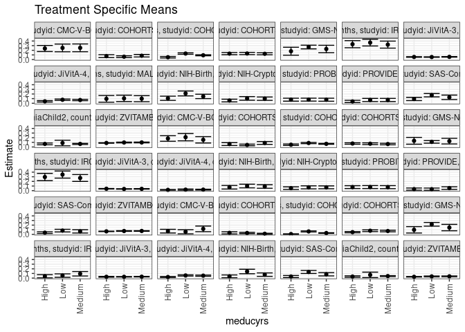

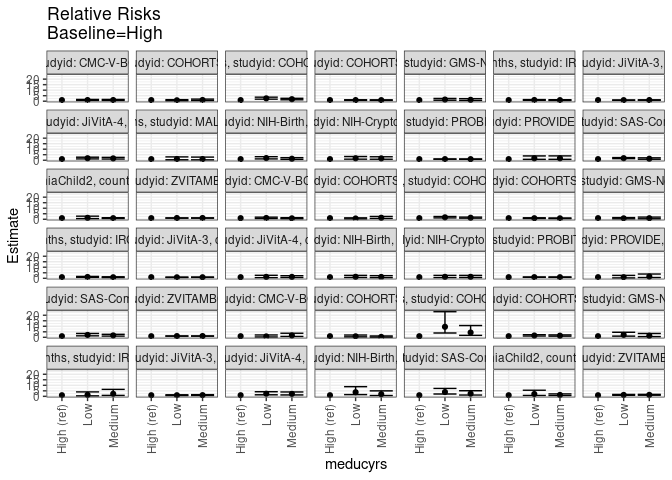

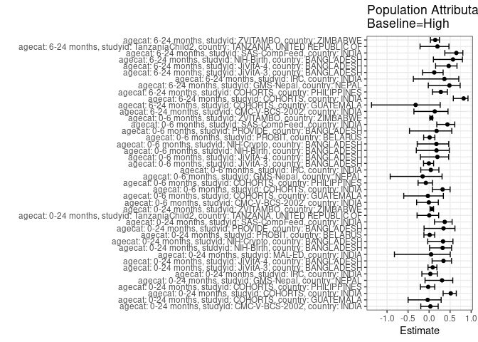

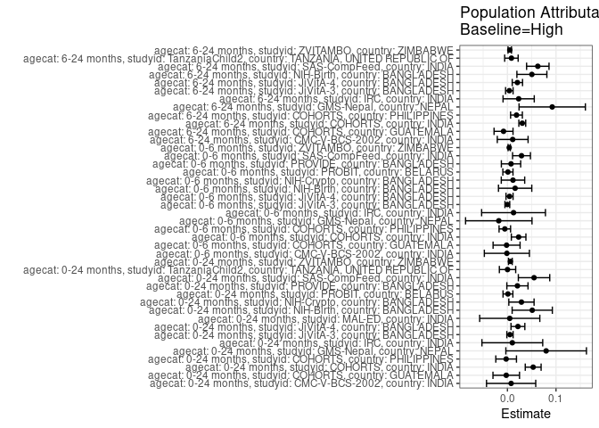

## Results Table

### Parameter: TSM

| agecat | studyid | country | intervention_level | baseline_level | estimate | ci_lower | ci_upper |
| --- | --- | --- | --- | --- | --- | --- | --- |
| 0-24 months | CMC-V-BCS-2002 | INDIA | High | NA | 0.2390491 | 0.1734764 | 0.3046218 |
| 0-24 months | CMC-V-BCS-2002 | INDIA | Low | NA | 0.2513253 | 0.1680539 | 0.3345966 |
| 0-24 months | CMC-V-BCS-2002 | INDIA | Medium | NA | 0.2525559 | 0.1690863 | 0.3360255 |
| 0-24 months | COHORTS | GUATEMALA | High | NA | 0.0735504 | 0.0429328 | 0.1041680 |
| 0-24 months | COHORTS | GUATEMALA | Low | NA | 0.0614567 | 0.0419016 | 0.0810119 |
| 0-24 months | COHORTS | GUATEMALA | Medium | NA | 0.0827495 | 0.0554506 | 0.1100483 |
| 0-24 months | COHORTS | INDIA | High | NA | 0.0500021 | 0.0336528 | 0.0663514 |
| 0-24 months | COHORTS | INDIA | Low | NA | 0.1299073 | 0.1144205 | 0.1453941 |
| 0-24 months | COHORTS | INDIA | Medium | NA | 0.0924015 | 0.0819590 | 0.1028439 |
| 0-24 months | COHORTS | PHILIPPINES | High | NA | 0.1281126 | 0.1039700 | 0.1522551 |
| 0-24 months | COHORTS | PHILIPPINES | Low | NA | 0.1309732 | 0.1066934 | 0.1552529 |
| 0-24 months | COHORTS | PHILIPPINES | Medium | NA | 0.1242603 | 0.1021186 | 0.1464020 |
| 0-24 months | GMS-Nepal | NEPAL | High | NA | 0.1794446 | 0.0934661 | 0.2654231 |
| 0-24 months | GMS-Nepal | NEPAL | Low | NA | 0.2704624 | 0.2301770 | 0.3107479 |
| 0-24 months | GMS-Nepal | NEPAL | Medium | NA | 0.2278010 | 0.1471435 | 0.3084586 |
| 0-24 months | IRC | INDIA | High | NA | 0.3313939 | 0.2546066 | 0.4081812 |
| 0-24 months | IRC | INDIA | Low | NA | 0.3654645 | 0.2930281 | 0.4379009 |
| 0-24 months | IRC | INDIA | Medium | NA | 0.3224479 | 0.2467449 | 0.3981508 |
| 0-24 months | JiVitA-3 | BANGLADESH | High | NA | 0.0558481 | 0.0487911 | 0.0629051 |
| 0-24 months | JiVitA-3 | BANGLADESH | Low | NA | 0.0541014 | 0.0486130 | 0.0595898 |
| 0-24 months | JiVitA-3 | BANGLADESH | Medium | NA | 0.0579111 | 0.0516091 | 0.0642132 |
| 0-24 months | JiVitA-4 | BANGLADESH | High | NA | 0.0415144 | 0.0260627 | 0.0569661 |
| 0-24 months | JiVitA-4 | BANGLADESH | Low | NA | 0.0758217 | 0.0605733 | 0.0910700 |
| 0-24 months | JiVitA-4 | BANGLADESH | Medium | NA | 0.0700094 | 0.0557437 | 0.0842751 |
| 0-24 months | MAL-ED | INDIA | High | NA | 0.0952381 | 0.0225874 | 0.1678888 |
| 0-24 months | MAL-ED | INDIA | Low | NA | 0.1052632 | 0.0361093 | 0.1744170 |
| 0-24 months | MAL-ED | INDIA | Medium | NA | 0.0987654 | 0.0336452 | 0.1638857 |
| 0-24 months | NIH-Birth | BANGLADESH | High | NA | 0.1075790 | 0.0622164 | 0.1529415 |
| 0-24 months | NIH-Birth | BANGLADESH | Low | NA | 0.2119573 | 0.1588411 | 0.2650735 |
| 0-24 months | NIH-Birth | BANGLADESH | Medium | NA | 0.1473430 | 0.1000613 | 0.1946247 |

[output cut: 96 more lines]

### Parameter: E(Y)

| agecat | studyid | country | intervention_level | baseline_level | estimate | ci_lower | ci_upper |
| --- | --- | --- | --- | --- | --- | --- | --- |
| 0-24 months | CMC-V-BCS-2002 | INDIA | NA | NA | 0.2466488 | 0.2028447 | 0.2904529 |
| 0-24 months | COHORTS | GUATEMALA | NA | NA | 0.0711044 | 0.0572455 | 0.0849633 |
| 0-24 months | COHORTS | INDIA | NA | NA | 0.1030116 | 0.0952175 | 0.1108057 |
| 0-24 months | COHORTS | PHILIPPINES | NA | NA | 0.1254516 | 0.1136848 | 0.1372183 |
| 0-24 months | GMS-Nepal | NEPAL | NA | NA | 0.2591508 | 0.2262659 | 0.2920357 |
| 0-24 months | IRC | INDIA | NA | NA | 0.3414634 | 0.2955068 | 0.3874201 |
| 0-24 months | JiVitA-3 | BANGLADESH | NA | NA | 0.0610653 | 0.0575838 | 0.0645468 |
| 0-24 months | JiVitA-4 | BANGLADESH | NA | NA | 0.0630996 | 0.0561390 | 0.0700602 |
| 0-24 months | MAL-ED | INDIA | NA | NA | 0.1000000 | 0.0602674 | 0.1397326 |
| 0-24 months | NIH-Birth | BANGLADESH | NA | NA | 0.1586538 | 0.1299648 | 0.1873429 |
| 0-24 months | NIH-Crypto | BANGLADESH | NA | NA | 0.0870712 | 0.0669870 | 0.1071555 |
| 0-24 months | PROBIT | BELARUS | NA | NA | 0.0784116 | 0.0458146 | 0.1110087 |
| 0-24 months | PROVIDE | BANGLADESH | NA | NA | 0.0600000 | 0.0423945 | 0.0776055 |
| 0-24 months | SAS-CompFeed | INDIA | NA | NA | 0.1473893 | 0.1184132 | 0.1763654 |
| 0-24 months | TanzaniaChild2 | TANZANIA, UNITED REPUBLIC OF | NA | NA | 0.0662196 | 0.0562399 | 0.0761994 |
| 0-24 months | ZVITAMBO | ZIMBABWE | NA | NA | 0.0922734 | 0.0874665 | 0.0970804 |
| 0-6 months | CMC-V-BCS-2002 | INDIA | NA | NA | 0.1820652 | 0.1425842 | 0.2215462 |
| 0-6 months | COHORTS | GUATEMALA | NA | NA | 0.0608944 | 0.0464300 | 0.0753587 |
| 0-6 months | COHORTS | INDIA | NA | NA | 0.0718095 | 0.0650627 | 0.0785562 |
| 0-6 months | COHORTS | PHILIPPINES | NA | NA | 0.0693167 | 0.0602923 | 0.0783411 |
| 0-6 months | GMS-Nepal | NEPAL | NA | NA | 0.1156662 | 0.0916631 | 0.1396693 |
| 0-6 months | IRC | INDIA | NA | NA | 0.3073171 | 0.2626027 | 0.3520314 |
| 0-6 months | JiVitA-3 | BANGLADESH | NA | NA | 0.0414166 | 0.0384340 | 0.0443992 |
| 0-6 months | JiVitA-4 | BANGLADESH | NA | NA | 0.0218633 | 0.0173413 | 0.0263853 |
| 0-6 months | NIH-Birth | BANGLADESH | NA | NA | 0.0900322 | 0.0675202 | 0.1125442 |
| 0-6 months | NIH-Crypto | BANGLADESH | NA | NA | 0.0659631 | 0.0482810 | 0.0836451 |
| 0-6 months | PROBIT | BELARUS | NA | NA | 0.0777153 | 0.0450748 | 0.1103558 |
| 0-6 months | PROVIDE | BANGLADESH | NA | NA | 0.0414286 | 0.0266555 | 0.0562017 |
| 0-6 months | SAS-CompFeed | INDIA | NA | NA | 0.0664452 | 0.0425975 | 0.0902929 |
| 0-6 months | ZVITAMBO | ZIMBABWE | NA | NA | 0.0688209 | 0.0646022 | 0.0730397 |
| 6-24 months | CMC-V-BCS-2002 | INDIA | NA | NA | 0.0804290 | 0.0527929 | 0.1080650 |
| 6-24 months | COHORTS | GUATEMALA | NA | NA | 0.0250417 | 0.0161900 | 0.0338934 |
| 6-24 months | COHORTS | INDIA | NA | NA | 0.0372331 | 0.0322193 | 0.0422468 |
| 6-24 months | COHORTS | PHILIPPINES | NA | NA | 0.0669277 | 0.0576848 | 0.0761707 |
| 6-24 months | GMS-Nepal | NEPAL | NA | NA | 0.1908007 | 0.1589868 | 0.2226146 |
| 6-24 months | IRC | INDIA | NA | NA | 0.0634146 | 0.0397960 | 0.0870333 |
| 6-24 months | JiVitA-3 | BANGLADESH | NA | NA | 0.0319444 | 0.0290509 | 0.0348380 |
| 6-24 months | JiVitA-4 | BANGLADESH | NA | NA | 0.0439439 | 0.0381166 | 0.0497712 |
| 6-24 months | NIH-Birth | BANGLADESH | NA | NA | 0.0885609 | 0.0646203 | 0.1125014 |
| 6-24 months | SAS-CompFeed | INDIA | NA | NA | 0.0964723 | 0.0729872 | 0.1199573 |
| 6-24 months | TanzaniaChild2 | TANZANIA, UNITED REPUBLIC OF | NA | NA | 0.0412730 | 0.0325768 | 0.0499692 |
| 6-24 months | ZVITAMBO | ZIMBABWE | NA | NA | 0.0329630 | 0.0295956 | 0.0363303 |

### Parameter: RR

| agecat | studyid | country | intervention_level | baseline_level | estimate | ci_lower | ci_upper |
| --- | --- | --- | --- | --- | --- | --- | --- |
| 0-24 months | CMC-V-BCS-2002 | INDIA | High | High | 1.0000000 | 1.0000000 | 1.000000 |
| 0-24 months | CMC-V-BCS-2002 | INDIA | Low | High | 1.0513542 | 0.6846748 | 1.614410 |
| 0-24 months | CMC-V-BCS-2002 | INDIA | Medium | High | 1.0565022 | 0.6895933 | 1.618631 |
| 0-24 months | COHORTS | GUATEMALA | High | High | 1.0000000 | 1.0000000 | 1.000000 |
| 0-24 months | COHORTS | GUATEMALA | Low | High | 0.8355729 | 0.4949809 | 1.410523 |
| 0-24 months | COHORTS | GUATEMALA | Medium | High | 1.1250717 | 0.6616586 | 1.913050 |
| 0-24 months | COHORTS | INDIA | High | High | 1.0000000 | 1.0000000 | 1.000000 |
| 0-24 months | COHORTS | INDIA | Low | High | 2.5980368 | 1.8341077 | 3.680152 |
| 0-24 months | COHORTS | INDIA | Medium | High | 1.8479515 | 1.3073937 | 2.612010 |
| 0-24 months | COHORTS | PHILIPPINES | High | High | 1.0000000 | 1.0000000 | 1.000000 |
| 0-24 months | COHORTS | PHILIPPINES | Low | High | 1.0223288 | 0.7896330 | 1.323597 |
| 0-24 months | COHORTS | PHILIPPINES | Medium | High | 0.9699307 | 0.7534770 | 1.248566 |
| 0-24 months | GMS-Nepal | NEPAL | High | High | 1.0000000 | 1.0000000 | 1.000000 |
| 0-24 months | GMS-Nepal | NEPAL | Low | High | 1.5072197 | 0.9121982 | 2.490370 |
| 0-24 months | GMS-Nepal | NEPAL | Medium | High | 1.2694784 | 0.6999913 | 2.302279 |
| 0-24 months | IRC | INDIA | High | High | 1.0000000 | 1.0000000 | 1.000000 |
| 0-24 months | IRC | INDIA | Low | High | 1.1028098 | 0.8232534 | 1.477297 |
| 0-24 months | IRC | INDIA | Medium | High | 0.9730047 | 0.7065301 | 1.339983 |
| 0-24 months | JiVitA-3 | BANGLADESH | High | High | 1.0000000 | 1.0000000 | 1.000000 |
| 0-24 months | JiVitA-3 | BANGLADESH | Low | High | 0.9687238 | 0.8277748 | 1.133673 |
| 0-24 months | JiVitA-3 | BANGLADESH | Medium | High | 1.0369393 | 0.8829742 | 1.217752 |
| 0-24 months | JiVitA-4 | BANGLADESH | High | High | 1.0000000 | 1.0000000 | 1.000000 |
| 0-24 months | JiVitA-4 | BANGLADESH | Low | High | 1.8263948 | 1.2102086 | 2.756317 |
| 0-24 months | JiVitA-4 | BANGLADESH | Medium | High | 1.6863878 | 1.0975507 | 2.591137 |
| 0-24 months | MAL-ED | INDIA | High | High | 1.0000000 | 1.0000000 | 1.000000 |
| 0-24 months | MAL-ED | INDIA | Low | High | 1.1052632 | 0.4038751 | 3.024714 |
| 0-24 months | MAL-ED | INDIA | Medium | High | 1.0370370 | 0.3783556 | 2.842421 |
| 0-24 months | NIH-Birth | BANGLADESH | High | High | 1.0000000 | 1.0000000 | 1.000000 |
| 0-24 months | NIH-Birth | BANGLADESH | Low | High | 1.9702485 | 1.2055538 | 3.219997 |
| 0-24 months | NIH-Birth | BANGLADESH | Medium | High | 1.3696262 | 0.8055428 | 2.328710 |

[output cut: 96 more lines]

### Parameter: PAR

| agecat | studyid | country | intervention_level | baseline_level | estimate | ci_lower | ci_upper |
| --- | --- | --- | --- | --- | --- | --- | --- |
| 0-24 months | CMC-V-BCS-2002 | INDIA | High | NA | 0.0075997 | -0.0430737 | 0.0582731 |
| 0-24 months | COHORTS | GUATEMALA | High | NA | -0.0024460 | -0.0297633 | 0.0248713 |
| 0-24 months | COHORTS | INDIA | High | NA | 0.0530095 | 0.0366842 | 0.0693349 |
| 0-24 months | COHORTS | PHILIPPINES | High | NA | -0.0026610 | -0.0239317 | 0.0186097 |
| 0-24 months | GMS-Nepal | NEPAL | High | NA | 0.0797062 | -0.0032633 | 0.1626757 |
| 0-24 months | IRC | INDIA | High | NA | 0.0100695 | -0.0525067 | 0.0726457 |
| 0-24 months | JiVitA-3 | BANGLADESH | High | NA | 0.0052172 | -0.0012391 | 0.0116735 |
| 0-24 months | JiVitA-4 | BANGLADESH | High | NA | 0.0215852 | 0.0073331 | 0.0358374 |
| 0-24 months | MAL-ED | INDIA | High | NA | 0.0047619 | -0.0571564 | 0.0666802 |
| 0-24 months | NIH-Birth | BANGLADESH | High | NA | 0.0510749 | 0.0096929 | 0.0924568 |
| 0-24 months | NIH-Crypto | BANGLADESH | High | NA | 0.0288600 | 0.0028639 | 0.0548560 |
| 0-24 months | PROBIT | BELARUS | High | NA | 0.0010675 | -0.0090673 | 0.0112024 |
| 0-24 months | PROVIDE | BANGLADESH | High | NA | 0.0205699 | -0.0012358 | 0.0423756 |
| 0-24 months | SAS-CompFeed | INDIA | High | NA | 0.0547871 | 0.0224632 | 0.0871109 |
| 0-24 months | TanzaniaChild2 | TANZANIA, UNITED REPUBLIC OF | High | NA | 0.0001971 | -0.0166125 | 0.0170066 |
| 0-24 months | ZVITAMBO | ZIMBABWE | High | NA | 0.0060437 | 0.0021833 | 0.0099040 |
| 0-6 months | CMC-V-BCS-2002 | INDIA | High | NA | -0.0011441 | -0.0475488 | 0.0452606 |
| 0-6 months | COHORTS | GUATEMALA | High | NA | -0.0017584 | -0.0295323 | 0.0260156 |
| 0-6 months | COHORTS | INDIA | High | NA | 0.0230468 | 0.0080486 | 0.0380449 |
| 0-6 months | COHORTS | PHILIPPINES | High | NA | -0.0053746 | -0.0172200 | 0.0064709 |
| 0-6 months | GMS-Nepal | NEPAL | High | NA | -0.0178025 | -0.0861781 | 0.0505732 |
| 0-6 months | IRC | INDIA | High | NA | 0.0125581 | -0.0531375 | 0.0782537 |
| 0-6 months | JiVitA-3 | BANGLADESH | High | NA | -0.0002191 | -0.0051624 | 0.0047242 |
| 0-6 months | JiVitA-4 | BANGLADESH | High | NA | 0.0043088 | -0.0029764 | 0.0115941 |
| 0-6 months | NIH-Birth | BANGLADESH | High | NA | 0.0158463 | -0.0184300 | 0.0501226 |
| 0-6 months | NIH-Crypto | BANGLADESH | High | NA | 0.0114325 | -0.0126689 | 0.0355339 |
| 0-6 months | PROBIT | BELARUS | High | NA | 0.0009888 | -0.0094581 | 0.0114356 |
| 0-6 months | PROVIDE | BANGLADESH | High | NA | 0.0073860 | -0.0124915 | 0.0272636 |
| 0-6 months | SAS-CompFeed | INDIA | High | NA | 0.0289671 | 0.0105758 | 0.0473584 |
| 0-6 months | ZVITAMBO | ZIMBABWE | High | NA | 0.0036728 | 0.0013562 | 0.0059893 |
| 6-24 months | CMC-V-BCS-2002 | INDIA | High | NA | 0.0108087 | -0.0208939 | 0.0425113 |
| 6-24 months | COHORTS | GUATEMALA | High | NA | -0.0080161 | -0.0275357 | 0.0115035 |
| 6-24 months | COHORTS | INDIA | High | NA | 0.0305664 | 0.0235113 | 0.0376215 |
| 6-24 months | COHORTS | PHILIPPINES | High | NA | 0.0186259 | 0.0065161 | 0.0307357 |
| 6-24 months | GMS-Nepal | NEPAL | High | NA | 0.0922091 | 0.0239190 | 0.1604993 |
| 6-24 months | IRC | INDIA | High | NA | 0.0230921 | -0.0090432 | 0.0552273 |
| 6-24 months | JiVitA-3 | BANGLADESH | High | NA | 0.0039091 | -0.0038138 | 0.0116321 |
| 6-24 months | JiVitA-4 | BANGLADESH | High | NA | 0.0204858 | 0.0098657 | 0.0311060 |
| 6-24 months | NIH-Birth | BANGLADESH | High | NA | 0.0503443 | 0.0194871 | 0.0812016 |
| 6-24 months | SAS-CompFeed | INDIA | High | NA | 0.0625421 | 0.0394497 | 0.0856345 |
| 6-24 months | TanzaniaChild2 | TANZANIA, UNITED REPUBLIC OF | High | NA | 0.0081991 | -0.0056758 | 0.0220739 |
| 6-24 months | ZVITAMBO | ZIMBABWE | High | NA | 0.0048052 | 0.0012394 | 0.0083711 |

### Parameter: PAF

| agecat | studyid | country | intervention_level | baseline_level | estimate | ci_lower | ci_upper |
| --- | --- | --- | --- | --- | --- | --- | --- |
| 0-24 months | CMC-V-BCS-2002 | INDIA | High | NA | 0.0308119 | -0.1978403 | 0.2158173 |
| 0-24 months | COHORTS | GUATEMALA | High | NA | -0.0344002 | -0.4997440 | 0.2865558 |
| 0-24 months | COHORTS | INDIA | High | NA | 0.5145975 | 0.3333304 | 0.6465782 |
| 0-24 months | COHORTS | PHILIPPINES | High | NA | -0.0212114 | -0.2057040 | 0.1350508 |
| 0-24 months | GMS-Nepal | NEPAL | High | NA | 0.3075669 | -0.0967314 | 0.5628249 |
| 0-24 months | IRC | INDIA | High | NA | 0.0294892 | -0.1721565 | 0.1964458 |
| 0-24 months | JiVitA-3 | BANGLADESH | High | NA | 0.0854360 | -0.0262843 | 0.1849946 |
| 0-24 months | JiVitA-4 | BANGLADESH | High | NA | 0.3420818 | 0.0715921 | 0.5337649 |
| 0-24 months | MAL-ED | INDIA | High | NA | 0.0476190 | -0.8241477 | 0.5027653 |
| 0-24 months | NIH-Birth | BANGLADESH | High | NA | 0.3219265 | 0.0115394 | 0.5348487 |
| 0-24 months | NIH-Crypto | BANGLADESH | High | NA | 0.3314522 | -0.0319665 | 0.5668889 |
| 0-24 months | PROBIT | BELARUS | High | NA | 0.0136144 | -0.1233966 | 0.1339154 |
| 0-24 months | PROVIDE | BANGLADESH | High | NA | 0.3428319 | -0.1201347 | 0.6144483 |
| 0-24 months | SAS-CompFeed | INDIA | High | NA | 0.3717168 | 0.1283742 | 0.5471224 |
| 0-24 months | TanzaniaChild2 | TANZANIA, UNITED REPUBLIC OF | High | NA | 0.0029760 | -0.2861107 | 0.2270830 |
| 0-24 months | ZVITAMBO | ZIMBABWE | High | NA | 0.0654974 | 0.0227998 | 0.1063293 |
| 0-6 months | CMC-V-BCS-2002 | INDIA | High | NA | -0.0062842 | -0.2964011 | 0.2189085 |
| 0-6 months | COHORTS | GUATEMALA | High | NA | -0.0288757 | -0.6029960 | 0.3396208 |
| 0-6 months | COHORTS | INDIA | High | NA | 0.3209434 | 0.0789375 | 0.4993631 |
| 0-6 months | COHORTS | PHILIPPINES | High | NA | -0.0775364 | -0.2623305 | 0.0802055 |
| 0-6 months | GMS-Nepal | NEPAL | High | NA | -0.1539125 | -0.9250257 | 0.3083136 |
| 0-6 months | IRC | INDIA | High | NA | 0.0408636 | -0.1985435 | 0.2324495 |
| 0-6 months | JiVitA-3 | BANGLADESH | High | NA | -0.0052911 | -0.1320607 | 0.1072827 |
| 0-6 months | JiVitA-4 | BANGLADESH | High | NA | 0.1970798 | -0.2069821 | 0.4658738 |
| 0-6 months | NIH-Birth | BANGLADESH | High | NA | 0.1760072 | -0.3047007 | 0.4796015 |
| 0-6 months | NIH-Crypto | BANGLADESH | High | NA | 0.1733167 | -0.2828438 | 0.4672732 |
| 0-6 months | PROBIT | BELARUS | High | NA | 0.0127228 | -0.1294626 | 0.1370088 |
| 0-6 months | PROVIDE | BANGLADESH | High | NA | 0.1782832 | -0.4663291 | 0.5395178 |
| 0-6 months | SAS-CompFeed | INDIA | High | NA | 0.4359547 | 0.1831366 | 0.6105260 |
| 0-6 months | ZVITAMBO | ZIMBABWE | High | NA | 0.0533672 | 0.0191676 | 0.0863744 |
| 6-24 months | CMC-V-BCS-2002 | INDIA | High | NA | 0.1343882 | -0.3612271 | 0.4495527 |
| 6-24 months | COHORTS | GUATEMALA | High | NA | -0.3201102 | -1.3687346 | 0.2642946 |
| 6-24 months | COHORTS | INDIA | High | NA | 0.8209477 | 0.5757824 | 0.9244262 |
| 6-24 months | COHORTS | PHILIPPINES | High | NA | 0.2782983 | 0.0789976 | 0.4344713 |
| 6-24 months | GMS-Nepal | NEPAL | High | NA | 0.4832746 | -0.0191883 | 0.7380218 |
| 6-24 months | IRC | INDIA | High | NA | 0.3641439 | -0.3738866 | 0.7057159 |
| 6-24 months | JiVitA-3 | BANGLADESH | High | NA | 0.1223725 | -0.1553677 | 0.3333464 |
| 6-24 months | JiVitA-4 | BANGLADESH | High | NA | 0.4661818 | 0.1544109 | 0.6630020 |
| 6-24 months | NIH-Birth | BANGLADESH | High | NA | 0.5684713 | 0.1027881 | 0.7924493 |
| 6-24 months | SAS-CompFeed | INDIA | High | NA | 0.6482909 | 0.3742772 | 0.8023098 |
| 6-24 months | TanzaniaChild2 | TANZANIA, UNITED REPUBLIC OF | High | NA | 0.1986545 | -0.2153224 | 0.4716180 |
| 6-24 months | ZVITAMBO | ZIMBABWE | High | NA | 0.1457758 | 0.0316539 | 0.2464481 |